# Lecture 2 Exercises

## Short Questions

1. How do you check whether an element is part of a list?
2. How do you reference a global variable in `.query()`?

```python
# Write your answers here as comments:

#1 You can use the "in" condition to check if a string is within a list.
#2 Using the @ sign is how to reference a global variable.
```

## Long Questions

Import the pandas and matplotlib packages

```python
# Write your own code

import pandas as pd
import numpy as np
import matplotlib.pyplot as plt
```

(a) Checking a string condition

- Define a variable "fruit" with the value "apple"
- Define a list

list_fruits = ["banana","orange","apple"]

- Write an expression to test whether "fruit" is contained in "list_fruits"

Hint: Use the "in" command. The final output should be True/False.

To get full points run all of the above commands

```python
# Write your own code

fruit = 'apple'

list_fruits = ['banana', 'orange', 'apple']

print(fruit in list_fruits)
```

```
True
```

(b) Classifying a variable

- Define a new variable "year" an assign the value "2008"
- Write an if/else statement that does the following
  - print("Year 2000 or earlier") if the year is less than or equal to 2000.
  - print("Between 2001 and 2005") if the year is between 2001 and 2005.
  - print("Year 2006 or later") if the year is after 2005.

To get full points you must do all of the above instructions

```python
# Write your own code

year = 2008

if year <= 2000:
    print("Year 2000 or earlier")
elif year >= 2001 and year <= 2005:
    print("Between 2001 and 2005")
elif year > 2005:
    print("Year 2005 or later")
```

```
Year 2005 or later
```

(c) Split a dataset into subsets

- Create `list_status = [0,1]`
- Create `list_prob = [0.5, 0.5]`
- Create a new variable $n = 1000$ with the number of rows of the dataset
- Use

```
    np.random.choice(list_status,
                     size = n,
                     p = list_prob)
```

$\qquad$ to create a new column called "status"  
$\qquad$ which randomly assigns each row to "0" or "1"  
$\qquad$ with equal probability

- Use .query() to subset all observations with status == 0.  
  store it in a new dataset called "data0"
- Use .query() to subset all observations with status == 1.  
  store it in a new dataset called "data1"

```python
# Write your own code


list_status = [0, 1]
list_prob = [0.5, 0.5]
n = 1000


df = pd.DataFrame({
    "status": np.random.choice(list_status, size=n, p=list_prob)
})


data0 = df.query("status == 0")
data1 = df.query("status == 1")


print(data0)
print(data1)
```

```
     status
0         0
4         0
8         0
9         0
10        0
..      ...
988       0
989       0
996       0
998       0
999       0

[511 rows x 1 columns]
     status
1         1
2         1
3         1
5         1
6         1
..      ...
992       1
993       1
994       1
995       1
997       1

[489 rows x 1 columns]
```

For questions (d) through (f) mport the dataset  
"data_raw/fifa23_players_basic.csv"

- It's a dataset on professional soccer players
- Rows correspond to players (18,539)
- Columns contain attributes of players (32)
- Try to view the dataset before starting

```python
# Write your own code

fifa_players = pd.read_csv("data_raw/fifa23_players_basic.csv")
fifa_players.head()
```

|  | Known As | Full Name | Overall | Potential | Value(in Euro) | Positions Played | Best Position | Nationality | Image Link | Age | ... | Preferred Foot | Weak Foot Rating | Skill Moves | International Reputation | National Team Name | National Team Image Link | National Team Position | National Team Jersey Number | Attacking Work Rate | Defensive Work Rate |
| --- | --- | --- | --- | --- | --- | --- | --- | --- | --- | --- | --- | --- | --- | --- | --- | --- | --- | --- | --- | --- | --- |
| 0 | L. Messi | Lionel Messi | 91 | 91 | 54000000 | RW | CAM | Argentina | https://cdn.sofifa.net/players/158/023/23_60.png | 35 | ... | Left | 4 | 4 | 5 | Argentina | https://cdn.sofifa.net/flags/ar.png | RW | 10 | Low | Low |
| 1 | K. Benzema | Karim Benzema | 91 | 91 | 64000000 | CF,ST | CF | France | https://cdn.sofifa.net/players/165/153/23_60.png | 34 | ... | Right | 4 | 4 | 4 | France | https://cdn.sofifa.net/flags/fr.png | ST | 19 | Medium | Medium |
| 2 | R. Lewandowski | Robert Lewandowski | 91 | 91 | 84000000 | ST | ST | Poland | https://cdn.sofifa.net/players/188/545/23_60.png | 33 | ... | Right | 4 | 4 | 5 | Poland | https://cdn.sofifa.net/flags/pl.png | ST | 9 | High | Medium |
| 3 | K. De Bruyne | Kevin De Bruyne | 91 | 91 | 107500000 | CM,CAM | CM | Belgium | https://cdn.sofifa.net/players/192/985/23_60.png | 31 | ... | Right | 5 | 4 | 4 | Belgium | https://cdn.sofifa.net/flags/be.png | RF | 7 | High | High |
| 4 | K. Mbappé | Kylian Mbappé | 91 | 95 | 190500000 | ST,LW | ST | France | https://cdn.sofifa.net/players/231/747/23_60.png | 23 | ... | Right | 4 | 5 | 4 | France | https://cdn.sofifa.net/flags/fr.png | ST | 10 | High | Low |

5 rows × 32 columns

(d) Create a new dataset subsetting the  
players whose age is less than 20

```python
# Write your own code

young_dudes = fifa_players[fifa_players['Age'] < 20]
print(young_dudes)
```

```
            Known As             Full Name  Overall  Potential  \
82             Pedri  Pedro González López       85         93
124    J. Bellingham       Jude Bellingham       84         91
225         F. Wirtz         Florian Wirtz       82         91
302       J. Musiala         Jamal Musiala       81         90
527        Ansu Fati        Anssumane Fati       79         90
...              ...                   ...      ...        ...
18530         S. Bag             Sajal Bag       48         61
18533      Pi Ziyang             Ziyang Pi       47         60
18535   Yang Dejiang          Dejiang Yang       47         57
18536      L. Mullan           Liam Mullan       47         67
18537   D. McCallion      Daithí McCallion       47         61

       Value(in Euro) Positions Played Best Position          Nationality  \
82          116000000               CM            CM                Spain
```

[output cut: 77 more lines]

(e) Use queries + global variables

- Compute the mean of the column "Value(in Euro)"  
  and store it as a variable
- Subset the players whose value is above the mean value  
  using ".query()"

HINT: Remember that there is a special syntax for  
when the column names have spaces (see Lecture 10)  
Reference the column as `` `Value(in Euro)` `` inside .query()

```python
# Write your own code

mean_value = fifa_players['Value(in Euro)'].mean()
print(mean_value)

above_mean = fifa_players.query("`Value(in Euro)` > @mean_value")
print(above_mean)
```

[output not shown]

[output not shown]

(f) Use sorting + ".iloc[]"

- Use ".sort_values()" to order the "Age" column  
  from youngest to oldest
- Get a subset with the 5 youngest players

```python
# Write your own code

fifa_players_youngest = fifa_players.sort_values(by='Age')
print(fifa_players_youngest)

fifa_players_youngest = fifa_players.sort_values(by='Age').iloc[0:5]
print(fifa_players_youngest)
```

```
           Known As          Full Name  Overall  Potential  Value(in Euro)  \
18425     M. Moraru       Matei Moraru       50         72          150000
18232     B. Faraas    Benjamin Faraas       51         76          180000
18284    D. Lipsiuc     Darius Lipsiuc       51         65          130000
18014     J. Ardila        José Ardila       53         73          250000
16880   M. Kowalski   Mateusz Kowalski       56         75          350000
...             ...                ...      ...        ...             ...
4499      G. Pegolo    Gianluca Pegolo       70         70          180000
7701   N. Penneteau  Nicolas Penneteau       67         67          110000
13548      S. Lukić       Stojan Lukić       62         62           45000
3276     S. Torrico  Sebastián Torrico       72         72          250000
592       G. Buffon   Gianluigi Buffon       79         79         1900000

      Positions Played Best Position             Nationality  \
18425            CM,RW           CAM                 Romania
```

[output cut: 77 more lines]

For questions (h)-(i), read "data_raw/wdi_2020.csv"  
This is a dataset of countries from  
the World Development Indicators

(g) Extract sorted elements from a dataset

- Sort by "prop_urbanpopulation" in descending order
- Subset the 5 countries with the highest urban population

```python
# Write your own code

wdi = pd.read_csv("data_raw/wdi_2020.csv")
wdi_sorted = wdi.sort_values(by="prop_urbanpopulation", ascending=False)
top_5 = wdi_sorted.iloc[0:5]
print(top_5)
```

```
     year yearcode                countryname countrycode  \
213  2020   YR2020  Sint Maarten (Dutch part)         SXM
24   2020   YR2020                    Bermuda         BMU
103  2020   YR2020       Hong Kong SAR, China         HKG
90   2020   YR2020                  Gibraltar         GIB
212  2020   YR2020                  Singapore         SGP

     prop_urbanpopulation
213                 100.0
24                  100.0
103                 100.0
90                  100.0
212                 100.0
```

(h) Subset elements with query

- Compute the median of "prop_urbanpopulation"
- Use ".query()" to subset countries with  
  "prop_urbanpopulation" above the median

```python
# Write your own code

median_pop = wdi['prop_urbanpopulation'].median()
print(median_pop)
above_median = wdi.query("prop_urbanpopulation > @median_pop")
print(above_median)
```

[output not shown]

[output not shown]

(i) Plot by category

- Read "data_raw/wdi_urban.csv"  
  This contains data from 1980 and 2020
- Create a list with the unique values of "year"
- Create a plot with a ...
  - Histogram of "prop_urbanpopulation"  
    for each year
  - Set the histogram option `alpha = 0.5` for transparency
  - All the histograms should be overlapping
  - Create a legend with the list of years
  - Label the axes and the title

What do we learn from the graph?

HINT: See the example at the end of Lecture 10

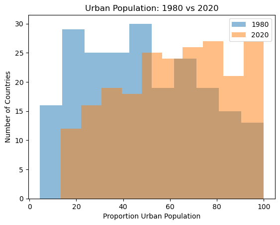

```python
import matplotlib.pyplot as plt

# Subset the data for each year
urban_1980 = urban_data[urban_data['year'] == 1980]
urban_2020 = urban_data[urban_data['year'] == 2020]

# Plot overlapping histograms
plt.hist(urban_1980['prop_urbanpopulation'], alpha=0.5, label="1980")
plt.hist(urban_2020['prop_urbanpopulation'], alpha=0.5, label="2020")

# Add labels, title, and legend
plt.xlabel("Proportion Urban Population")
plt.ylabel("Number of Countries")
plt.title("Urban Population: 1980 vs 2020")
plt.legend()
plt.show()
```

# Review of last lecture

(k) Composite operations on arrays

- Define $r = 0.04$
- Define two arrays $A$ and $T$ using "np.array()", assigning the following values

$ a = \begin{pmatrix} a_0 \\ a_1 \\ a_2 \end{pmatrix} = \begin{pmatrix} 20 \\ 30 \\ 15 \end{pmatrix}, \qquad t = \begin{pmatrix} t_0 \\ t_1 \\ t_2 \end{pmatrix} = \begin{pmatrix} 0 \\ 1 \\ 2 \end{pmatrix} $

- Use element-by-element vector operations to compute a new array $M$ of length 3:

$ M = \begin{pmatrix} a_1 / (1+r)^{t_0} \\ a_2 / (1+r)^{t_1} \\ a_3 / (1+r)^{t_2} \end{pmatrix} $

- Compute the sum of the values of $M$ using "M.sum()"

Note: I am using subscripts to denote the individual elements of $a$ and $t$.

- In the code just enter the values of $a$ and $t$.
- To get full points you must do all of the above tasks

```python
# Write your own code

import numpy as np

R = .04

vec_a = np.array([20, 30, 15])
vec_t = np.array([0, 1, 2])

M = vec_a / (1 + R) ** vec_t


result = M.sum()

print("M =", M)
print("Sum M =", result)
```

```
M = [20.         28.84615385 13.8683432 ]
Sum M = 62.71449704142012
```